# Oxford flowers classifier

In this project, we train an image classifier to recognize different species of flowers. We'll be using [this dataset](http://www.robots.ox.ac.uk/~vgg/data/flowers/102/index.html) from Oxford of 102 flower categories.

The project is broken down into multiple steps:

- Load the image dataset and create a pipeline.
- Build and Train the image classifier on this dataset.
- Use the trained model to perform inference on flower images.

After we've trained our model we'll bind this to a command line application.

## Import Resources

```python
# necessary imports.

import numpy as np
import json
import matplotlib.pyplot as plt
import tensorflow as tf
import tensorflow_datasets as tfds
import tensorflow_hub as hub
from tensorflow.keras.preprocessing.image import ImageDataGenerator
from PIL import Image

import warnings
warnings.filterwarnings('ignore')
```

## Load the Dataset

Let's use `tensorflow_datasets` to load the [Oxford Flowers 102 dataset](https://www.tensorflow.org/datasets/catalog/oxford_flowers102). This dataset has 3 splits: `'train'`, `'test'`, and `'validation'`.

```python
# Load the dataset with TensorFlow Datasets.
ds, ds_info = tfds.load('oxford_flowers102', as_supervised=True, with_info=True)

training_set = ds['train']
validation_set = ds['validation']
test_set = ds['test']
```

## Explore the Dataset

```python
print(ds_info)
```

```
tfds.core.DatasetInfo(
    name='oxford_flowers102',
    full_name='oxford_flowers102/2.1.1',
    description="""
    The Oxford Flowers 102 dataset is a consistent of 102 flower categories commonly occurring
    in the United Kingdom. Each class consists of between 40 and 258 images. The images have
    large scale, pose and light variations. In addition, there are categories that have large
    variations within the category and several very similar categories.

    The dataset is divided into a training set, a validation set and a test set.
    The training set and validation set each consist of 10 images per class (totalling 1020 images each).
    The test set consists of the remaining 6149 images (minimum 20 per class).

    Note: The dataset by default comes with a test size larger than the train
    size. For more info see this [issue](https://github.com/tensorflow/datasets/issues/3022).
    """,
    homepage='https://www.robots.ox.ac.uk/~vgg/data/flowers/102/',
    data_path='C:\\Users\\vagge\\tensorflow_datasets\\oxford_flowers102\\2.1.1',
    download_size=328.90 MiB,
    dataset_size=331.34 MiB,
    features=FeaturesDict({
        'file_name': Text(shape=(), dtype=tf.string),
        'image': Image(shape=(None, None, 3), dtype=tf.uint8),
        'label': ClassLabel(shape=(), dtype=tf.int64, num_classes=102),
    }),
    supervised_keys=('image', 'label'),
    disable_shuffling=False,
    splits={
        'test': <SplitInfo num_examples=6149, num_shards=2>,
        'train': <SplitInfo num_examples=1020, num_shards=1>,
        'validation': <SplitInfo num_examples=1020, num_shards=1>,
    },
    citation="""@InProceedings{Nilsback08,
       author = "Nilsback, M-E. and Zisserman, A.",
       title = "Automated Flower Classification over a Large Number of Classes",
       booktitle = "Proceedings of the Indian Conference on Computer Vision, Graphics and Image Processing",
       year = "2008",
       month = "Dec"
    }""",
)
```

```python
# number of examples in each set from the dataset info.
train_num = ds_info.splits['train'].num_examples
validation_num = ds_info.splits['validation'].num_examples
test_num = ds_info.splits['test'].num_examples
# number of classes in the dataset from the dataset info.
print("train number: {}, validation number {}, test number {}".format(train_num, validation_num, test_num))
print("Number of classes: {}".format(ds_info.features['label'].num_classes))
```

```
train number: 1020, validation number 1020, test number 6149
Number of classes: 102
```

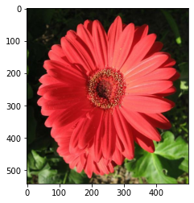

```
The label of the image is 40 and it's shape is (542, 500, 3)
```

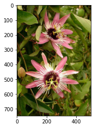

```
The label of the image is 76 and it's shape is (748, 500, 3)
```

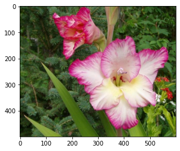

```
The label of the image is 42 and it's shape is (500, 600, 3)
```

```python
# Print the shape and corresponding label of 3 images in the training set.
for image, label in test_set.take(3):
    image = image.numpy().squeeze()
    label = label.numpy()

    plt.imshow(image, cmap=plt.cm.binary)
    plt.colorbar
    plt.show()
    print("The label of the image is {} and it's shape is {}".format(label, image.shape))
```

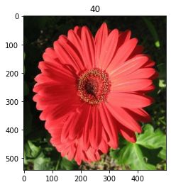

```python
# Plot 1 image from the training set. Set the title
# of the plot to the corresponding image label.
for image, label in test_set.take(1):
    image = image.numpy().squeeze()
    label = label.numpy()

    plt.imshow(image, cmap=plt.cm.binary)
    plt.colorbar
    plt.title(label)
    plt.show()
```

### Label Mapping

We also need to load in a mapping from label to category name. We can find this in the file `label_map.json`.

```python
with open('label_map.json', 'r') as f:
    class_names = json.load(f)

print(class_names)
```

[output not shown]

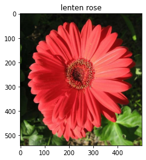

```python
# TODO: Plot 1 image from the training set. Set the title
# of the plot to the corresponding class name.
for image, label in test_set.take(1):
    image = image.numpy().squeeze()
    label = label.numpy()
    class_name = class_names[str(label)]

    plt.imshow(image, cmap=plt.cm.binary)
    plt.colorbar
    plt.title(class_name)
    plt.show()
```

## Create Pipeline

```python
# Create a pipeline for each set.
def norm_resize(image, label):
    image = tf.cast(image, tf.float32)
    image /= 255 # normalize
    image = tf.image.resize(image, [224, 224]) # resize to size used on the pre-trsained networks
    return image, label

batch_size = 32
training_batches = training_set.cache().shuffle(train_num//4).map(norm_resize).batch(batch_size).prefetch(1) # map before batch to avoid errors
validation_batches = validation_set.cache().map(norm_resize).batch(batch_size).prefetch(1)
test_batches = test_set.cache().map(norm_resize).batch(batch_size).prefetch(1)
```

```python
print(training_set)
tf.print(training_batches)
```

```
<PrefetchDataset shapes: ((None, None, 3), ()), types: (tf.uint8, tf.int64)>
<PrefetchDataset shapes: ((None, 224, 224, 3), (None,)), types: (tf.float32, tf.int64)>
```

# Build and Train the Classifier

Now that the data is ready, it's time to build and train the classifier. We will use the MobileNet pre-trained model from TensorFlow Hub to get the image features. We will build and train a new feed-forward classifier using those features.

In particular we will:

- Load the MobileNet pre-trained network from TensorFlow Hub.
- Define a new, untrained feed-forward network as a classifier.
- Train the classifier.
- Plot the loss and accuracy values achieved during training for the training and validation set.
- Save your trained model as a Keras model.

```python
# Build and train the network.
mobilenet_v2 = "https://tfhub.dev/google/tf2-preview/mobilenet_v2/feature_vector/4"
mobile_net_layers = hub.KerasLayer(mobilenet_v2, input_shape=(224,224,3))
mobile_net_layers.trainable = False # freeze all mobile net layers (untrainable)

neural_net = tf.keras.Sequential([
  mobile_net_layers,
#   tf.keras.layers.Dropout(0.3),
  tf.keras.layers.Dense(102,activation='softmax') # add a dense layer to with 102 nodes to match the number of classes
])

neural_net.summary() # print our model
```

```
Model: "sequential"
_________________________________________________________________
Layer (type)                 Output Shape              Param #
=================================================================
keras_layer (KerasLayer)     (None, 1280)              2257984
_________________________________________________________________
dense (Dense)                (None, 102)               130662
=================================================================
Total params: 2,388,646
Trainable params: 130,662
Non-trainable params: 2,257,984
_________________________________________________________________
```

```python
neural_net.compile(
  optimizer='adam',
  loss='sparse_categorical_crossentropy',
  metrics='accuracy')

EPOCHS = 6
```

```python
model_fit = neural_net.fit(training_batches, epochs=EPOCHS, validation_data=validation_batches)
```

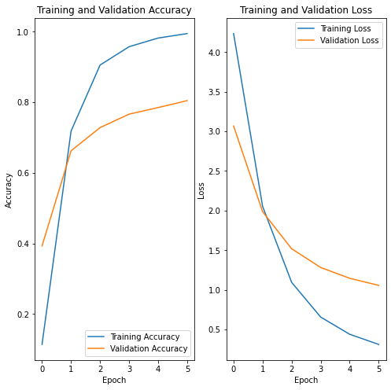

```python
# TODO: Plot the loss and accuracy values achieved during training for the training and validation set.
acc = model_fit.history['accuracy'] # training accuracy
val_acc = model_fit.history['val_accuracy'] # validation accuracy

loss = model_fit.history['loss'] # training loss
val_loss = model_fit.history['val_loss'] # validation loss

epochs_range = range(EPOCHS)

plt.figure(figsize=(8, 8))
plt.subplot(1, 2, 1)
plt.plot(epochs_range, acc, label='Training Accuracy')
plt.plot(epochs_range, val_acc, label='Validation Accuracy')
plt.legend(loc='lower right')
plt.title('Training and Validation Accuracy')
plt.ylabel("Accuracy")
plt.xlabel("Epoch")

plt.subplot(1, 2, 2)
plt.plot(epochs_range, loss, label='Training Loss')
plt.plot(epochs_range, val_loss, label='Validation Loss')
plt.legend(loc='upper right')
plt.title('Training and Validation Loss')
plt.ylabel('Loss')
plt.xlabel("Epoch")
plt.show()
```

## Testing the Network

It's good practice to test the trained network on test data, images the network has never seen either in training or validation. This will give us a good estimate for the model's performance on completely new images.

```python
# Print the loss and accuracy values achieved on the entire test set.

test_score=neural_net.evaluate(test_batches)
print('test loss, test acc:', test_score)
```

```
test loss, test acc: [1.1863594055175781, 0.757196307182312]
```

## Save the Model

Now that the network is trained, let's save the model so we can load it later for making inference.

```python
# Save the trained model as a Keras model.
path = "./flower_classifier.h5"
neural_net.save(path)
```

## Load the Keras Model

Load the Keras model we saved above.

```python
# Load the Keras model

loaded = tf.keras.models.load_model(path, custom_objects={'KerasLayer': hub.KerasLayer})
loaded.summary()
```

```
Model: "sequential"
_________________________________________________________________
Layer (type)                 Output Shape              Param #
=================================================================
keras_layer (KerasLayer)     (None, 1280)              2257984
_________________________________________________________________
dense (Dense)                (None, 102)               130662
=================================================================
Total params: 2,388,646
Trainable params: 130,662
Non-trainable params: 2,257,984
_________________________________________________________________
```

# Inference for Classification

We need to create a function for prediction. But first, we need a function that handles the necessary pre-processing transformations.

```python
# the process_image function, necessary transforms

def process_image(img):
    image = np.squeeze(img)
    image = tf.image.resize(image, (224, 224))/255.0
    return image
```

To check our `process_image` function we have 4 images in the `./test_images/` folder:

- cautleya_spicata.jpg
- hard-leaved_pocket_orchid.jpg
- orange_dahlia.jpg
- wild_pansy.jpg

The code below loads one of the above images using `PIL` and plots the original image alongside the image produced by the `process_image` function.

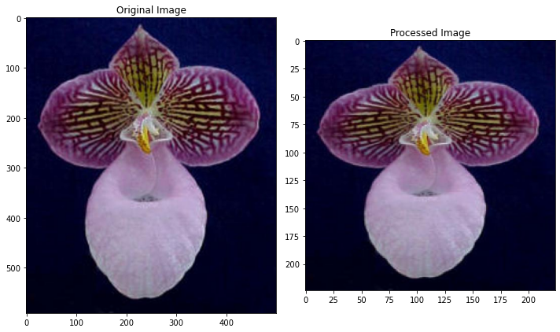

```python
image_path = './test_images/hard-leaved_pocket_orchid.jpg'
im = Image.open(image_path)
test_image = np.asarray(im)

processed_test_image = process_image(test_image)

fig, (ax1, ax2) = plt.subplots(figsize=(10,10), ncols=2)
ax1.imshow(test_image)
ax1.set_title('Original Image')
ax2.imshow(processed_test_image)
ax2.set_title('Processed Image')
plt.tight_layout()
plt.show()
```

### Inference

Now let's write a predict function for inference

```python
# the predict function

def predict(im_path, model, top_k):
    im = Image.open(im_path)
    test_image = np.asarray(im) # convert objet to np array
    test_image_proc = process_image(test_image)
    prediction = model.predict(np.expand_dims(test_image_proc, axis=0))
    top_probs, top_indices = tf.math.top_k(prediction, top_k) # keep only k best
    print("Top propabilities",top_probs.numpy()[0])
    top_classes = [class_names[str(value+1)] for value in top_indices.numpy()[0]] # +1 cause labels range from 1 to 102
    print('Top classes', top_classes)
    return top_probs.numpy()[0], top_classes
```

# Sanity Check

It's always good to check the predictions made by your model to make sure they are correct. To check our predictions we will use the 4 images in the `./test_images/` folder:

- cautleya_spicata.jpg
- hard-leaved_pocket_orchid.jpg
- orange_dahlia.jpg
- wild_pansy.jpg

In the cell below we use `matplotlib` to plot the input image alongside the probabilities for the top 5 classes predicted by our model.

```
Top propabilities [0.6952134  0.09272464 0.03975859 0.0190279  0.01477273]
Top classes ['cautleya spicata', 'wallflower', 'red ginger', 'siam tulip', 'yellow iris']
```

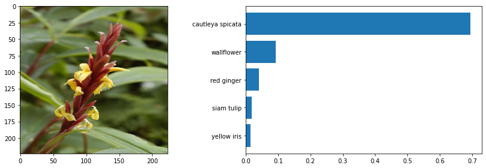

```
Top propabilities [9.9295205e-01 9.4860833e-04 7.0232415e-04 6.5978192e-04 5.6496868e-04]
Top classes ['hard-leaved pocket orchid', 'bearded iris', 'anthurium', 'moon orchid', 'tiger lily']
```

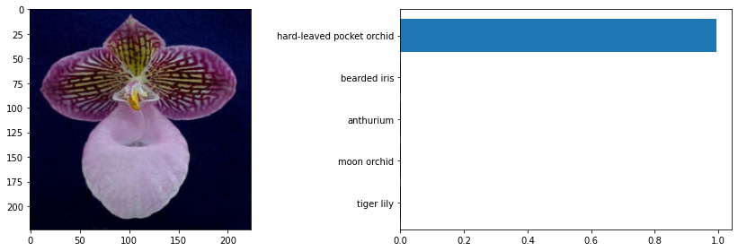

```
Top propabilities [0.29763663 0.15942694 0.08007693 0.05302098 0.04194928]
Top classes ['orange dahlia', 'english marigold', 'osteospermum', 'black-eyed susan', 'blanket flower']
```

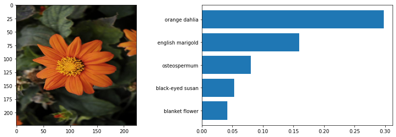

```
Top propabilities [0.9343449  0.00988568 0.00791788 0.00618273 0.00570444]
Top classes ['wild pansy', 'silverbush', 'balloon flower', 'windflower', 'mexican aster']
```

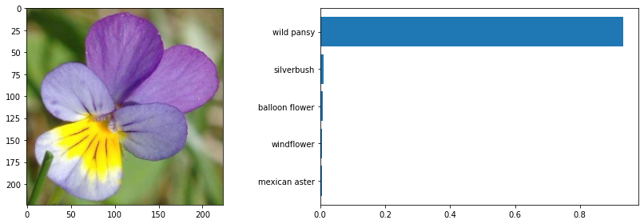

```python
# Plot the input image along with the top 5 classes
import glob # to parse directory
infer_images = glob.glob('./test_images/*.jpg')
for im_path in infer_images:
    im = Image.open(im_path)
    test_image = np.asarray(im)
    test_image_proc = process_image(test_image)
    probs, classes = predict(im_path, loaded, 5)
    fig, (ax1, ax2) = plt.subplots(figsize=(12,4), ncols=2)
    ax1.imshow(test_image_proc)
    ax2 = plt.barh(classes[::-1], probs[::-1])
    plt.tight_layout()
    plt.show()
```

# Future improvements

1. [Data augmentation](https://www.tensorflow.org/tutorials/images/data_augmentation), in the training images
2. [Dropout layers](https://www.tensorflow.org/tutorials/keras/overfit_and_underfit#add_dropout) in the neural network architecture
3. [Batch normalization](https://towardsdatascience.com/batch-normalization-in-practice-an-example-with-keras-and-tensorflow-2-0-b1ec28bde96f) during training